# Lecture 22: Faster & Smaller ZK Proofs

### Announcements

- Please pick up your card
- Will try to release Test 3 grades today
- Reading Assessment 12 is due Friday 12/5 at 6pm on Gradescope
- Homework Assignments
  - HW 9 is canceled (everyone receives full credit)
  - HW 10 will be due on Wed 12/10

### Learning outcomes

By the end of today’s lecture, you will learn:

- How to build a fast ZK proof using the ideas we learned about MPC
- How to build a succinct ZK proof using some fancier math

### Review from last lecture

Secure multi-party computation (MPC) solves a seemingly-impossible problem:

> Many people, each with their own private data that they do not want to share, can still **compute** data analysis collaboratively and only reveal the result!

Zero knowledge solves another seemingly-impossible problem:

> A prover can **convince** a verifier that a statement is true, without revealing the evidence or reason why!

Prover Peggy$(x, w)$

Verifier Victor$(x)$

$\begin{array}{c} \underset{\longleftarrow}{\pi} \\ \longrightarrow \\ \vdots \\ \longrightarrow \end{array}$

output: *Accept* or *Reject*

Before a ZK proof begins:

- Both parties know the claimed **statement** $x$ (e.g., a Sudoku puzzle) and an efficiently-computable check program $C(x, w)$ that tests whether a claimed solution $w$ actually solves the statement
- The prover Peggy also has a **witness** $w$ (e.g., solution to the Sukodu puzzle)

At the end of the protocol: the verifier Victor outputs its judgment about whether to **Accept** or **Reject** the claim that statement $x$ is true.

A zero knowledge proof satisfies three properties.

1. *Completeness*: if both Peggy and Victor are honest, then every valid proof should be accepted
2. *Soundness*: even if Peggy is dishonest, then every proof of an invalid statement (e.g., a Sudoku puzzle that has no solution) should be rejected
3. *Zero knowledgeness*: even if Victor is dishonest, it is infeasible to learn *anything* from the proof beyond the fact that the statement $x$ is true

Last time, we designed a zero knowledge proof for Sudoku puzzles. It turns out that any efficiently-checkable problem can be converted into a Sudoku puzzle, but this approach to ZK is inefficient in:

- Computation
- Interaction
- Communication

Today, we will discuss two new kinds of ZK proofs that perform better in these metrics.

## 22.1 ZK proofs from MPC

As a stepping stone toward today’s first construction, let’s imagine the following “hybrid” construction between ZK and MPC.

- As with zero knowledge: there is a public statement $x$, Peggy knows the solution $w$, and Victor wants to be convinced that Peggy knows it.
- As with MPC: Peggy and Victor have access to a collection of $n$ outsourced cloud servers. Assume that both Peggy and Victor trust that
  - none of the servers is actively malicious, and
  - at most $t$ of them would try to collude in order to recover any secret data.

Prover Peggy$(x, w)$

Verifier Victor$(x)$

$\begin{array}{c} \underset{\longleftarrow}{\pi} \\ \longrightarrow \\ \vdots \\ \longrightarrow \end{array}$

**Question.** How can Peggy and Victor take advantage of the outsourced cloud servers? Remember that Peggy wants to convince Victor that she knows $w$, but without sharing $w$ with Victor or the cloud servers.

**Construction.** Here is an idea:

1. Peggy acts as the data owner in the MPC protocol, and she provides secret shares of $w$ to all cloud servers. She also sends $x$ in the clear – remember that the statement $x$ is not meant to be a secret.
2. Given their shares $w_1, w_2, \ldots, w_n$: the cloud computing servers use MPC to securely compute the check program $C(x, w)$, which tests whether Peggy’s solution is correct. The computing servers obtain secret shares $y_1, y_2, \ldots, y_n$ of the answer.
3. Victor acts as the data analyst: he wants to know the result of $C(x, w)$. The outsourced servers send their shares of $y$ to Victor; once he has them all, he can use them to reconstruct $y$ itself.

   If $y$ = `true` then the verifier **Accepts** the proof, otherwise he **Rejects** the proof.

### Security analysis

**Theorem 1** If the computing servers use an MPC protocol that is secure against a passive eavesdropper Eve, then this construction achieves all of the requirements of a ZK proof.

Let’s see how we can use the MPC properties in order to satisfy the three requirements of zero knowledge.

- **Completeness** says that if everyone is honest, then valid statements will be accepted.

  This follows from the correctness of the MPC protocol: if the statement $x$ is true and Peggy has a valid witness $w$, then the outsourced servers will jointly calculate $y = C(x, w)$ correctly and give shares of $y$ to Victor.
- **Soundness** says that if the statement $x$ is false, then Victor will reject the proof.

  Once again this follows from the correctness of the MPC protocol. If the statement is false, then there is no witness $w$ that will cause $C(x, w)$ = `true`. So no matter what value $w^*$ that Peggy secret-shares with the outsourced servers, they will correctly compute $C(x, w^*)$ = `false` and Victor will reject the proof.
- **Zero-knowledgeness** says that Victor cannot learn anything from the proof, beyond the fact that the statement is true.

  This follows from the $t$-perfect secrecy of the underlying MPC protocol. Even if Victor is colluding with up to $t$ of the outsourced servers, those shares alone are insufficient to learn anything about the witness $w$, or anything else. All of the shares that the $t$ servers see are uniformly random, and Victor could have dreamed them up in his mind before the interaction with Peggy.

And that’s it! Let’s take a step back and admire what we’ve done here.

> If Peggy and Victor have access to a collection of outsourced servers, then they can use *any* MPC protocol in order to build a zero knowledge proof!

This idea will work using *any* MPC protocol, like the 3-party MPC protocol that we designed in Lecture 19.

## 22.2 ZK proofs from MPC-in-the-head

While the ZK proof we have built is elegant, it also suffers from a few drawbacks.

1. Peggy and Victor need to find a collection of outsourced servers to help them, and trust that they are not all colluding to reconstruct Peggy’s witness $w$
2. MPC protocols require a lot of network communication between the servers (which is often more expensive than computation on a commercial cloud)

So our next question is: can we do even better?

### An insight

Here is a wacky idea: what if Peggy runs **all** of the MPC computing servers by herself?

- This sounds strange! After all, MPC is about **multiple parties** computing together
- Remember that MPC only provided perfect secrecy if $\leq t$ of the computing servers are colluding

Prover Peggy$(x, w)$

Verifier Victor$(x)$

$\begin{array}{c} \underset{\longleftarrow}{\pi} \\ \longrightarrow \\ \vdots \\ \longrightarrow \end{array}$

If Peggy runs all $n$ servers, we cannot provide perfect secrecy against Peggy anymore.

- But that’s okay here since Peggy already knows all data (public statement $x$ and secret witness $w$)
- In our earlier analysis of zero knowledgeness, we only needed $t$-perfect secrecy to hold against *Victor*, not against Peggy

So here is our plan:

1. Peggy (who knows $x$ and $w$) acts as all computing servers, and executes the MPC protocol
2. Peggy provides shares $y_1, y_2, \ldots, y_n$ to Victor
3. Victor reconstructs $y = C(x, w)$ and he chooses to **Accept** the proof if $y$ = `true`

Note that we have removed the need for the MPC computing servers to send data over a network, since they are all running “in Peggy’s head.”

**Interactive question.** Is this a valid zero knowledge proof? (Hint: the plan does satisfy completeness.)

1. Yes, it satisfies soundness and zero knowledgeness
2. No, because Peggy can break soundness
3. No, because Victor can break zero knowledgeness

*Answer*. This plan satisfies zero-knowledgeness, but it does not satisfy soundness if Peggy is malicious.

- Right now, there is nothing that forces Peggy to execute an MPC protocol at all; she could just create shares of the boolean value `true` and send them to Victor
- We need something to **bind** the shares $y_1, y_2, \ldots, y_n$ to the execution of the MPC protocol

### Another insight

To fix this construction, we use a **message commitment scheme** to bind Peggy’s final responses.

In more detail, we require Peggy to commit to the **view** of each of the MPC compute servers, which contains:

- The server’s shares of the inputs ($x$ and $w$) and output ($y$)
- All messages this server sends and receives throughout the execution of the MPC protocol

[figure not shown]

MPC-in-the-head (source: [Trail of Bits blog](https://blog.trailofbits.com/2020/12/14/reverie-an-optimized-zero-knowledge-proof-system/))

So here is the new zero knowledge proof that Peggy and Victor can conduct, with changes from the previous version in italics.

1. Peggy is the data owner (she knows $w$). She acts as all computing servers, executes the MPC protocol, *and commits to each message sent by some party $i$ to some party $j$ (note that there are a total of $n \choose 2$ pairwise communication channels)*.
2. Peggy provides shares $y_1, y_2, \ldots, y_n$ to Victor.
3. *Victor challenges Peggy to open the state of $t$ servers. If Victor selects to open party $i$, then Peggy must decommit all messages sent or received by $i$. Then, Victor verifies that all of their work was honestly performed and that party $i$ reaches a final result of $y_i$. If any of these checks fail, he* **Rejects** *the proof*.
4. Victor reconstructs $y = C(x, w)$ and he chooses to **Accept** the proof if $y$ = `true`

**Interactive question.** Is this a valid zero knowledge proof? (Hint: completeness is still satisfied.)

1. Yes, it satisfies soundness and zero knowledgeness
2. No, because Peggy can break soundness
3. No, because Victor can break zero knowledgeness

*Answer*. Yes!

This construction is called “**MPC-in-the-head**,” because Peggy runs all of the computing servers herself rather than outsourcing it to external cloud providers. The only messages that are actually sent over the Internet are the 3 rounds of communication between Peggy and Victor.

### Security analysis

**Theorem 2** The MPC-in-the-head construction achieves all of the requirements of a ZK proof.

Let’s see why.

**Completeness** is true for the same reasons as before! Let me quote what we said earlier when Peggy and Victor were outsourcing the MPC computation to the outsourced servers.

> Completeness says that if everyone is honest, then valid statements will be accepted. This follows from the correctness of the MPC protocol: if the statement $x$ is true and Peggy has a valid witness $w$, then the outsourced servers will jointly calculate $y = C(x, w)$ correctly and give shares of $y$ to Victor.

Even if Peggy runs all of the compute servers herself, as long as she is honest then everything we discussed earlier is still true.

**Zero knowledgeness** also holds for similar reasons as before. Let me again quote our analysis from earlier today, when the MPC computation was outsourced to external cloud providers.

> Zero knowledgeness… follows from the $t$-perfect secrecy of the underlying MPC protocol. Even if Victor is colluding with up to $t$ of the outsourced servers, those shares alone are insufficient to learn anything about the witness $w$, or anything else.

In this new construction, Victor *is* colluding with $t$ of the servers… in the sense that Peggy intentionally allows Victor to view the internal state of $t$ servers. Even so, the $t$-perfect secrecy of the underlying MPC protocol guarantees that viewing only $t$ shares is insufficient to learn anything about any secret data.

We are not going to be so lucky with **soundness**; it is more complicated to think about now.

As a reminder, here is what we said before:

> Soundness says that if the statement $x$ is false, then Victor will reject the proof. Once again this follows from the correctness of the MPC protocol. If the statement is false, then there is no witness $w$ that will cause $C(x, w)$ = `true`. So no matter what value $w^*$ that Peggy secret-shares with the outsourced servers, they will correctly compute $C(x, w^*)$ = `false` and Victor will reject the proof.

**Question.** Why doesn’t this analysis work now, in the setting where Peggy runs all of the compute servers?

The issue is that Peggy can be dishonest, and she controls the MPC computing servers so she can run (some or all $n$ of) them in an actively malicious manner. We have not yet accounted for this possibility, since we started from an MPC protocol that is secure against a passive eavesdropper Eve.

Here is the good news.

- If the statement $x$ is false, then in order to run an MPC protocol that results in $y$ = `true`, then Peggy actually **must** have at least one compute party act in a faulty manner. If they were all honest, the result would be $y$ = `false` as desired.
- Victor inspects the state of $t$ of the computing servers, and can verify if they are acting in an honest or faulty manner.

Therefore, if Peggy has constructed a faulty party, then Victor has probability $t/n$ of catching her in this deceit. (And if Peggy ran all servers honestly, then Victor definitely won’t be fooled since the honest answer is `false`.)

So: if the statement is false, then Victor is fooled by Peggy with probability at most $\varepsilon = 1 - t/n$.

We can reduce the soundness error in the same way as in the last lecture – by repeating the protocol many times in parallel.

- If we run this procedure $k$ different times (with Peggy executing independent MPC instances each time, i.e., with fresh secret shares of the witness $w$) then the overall soundness error is $\left( 1 - \frac{t}{n}\right)^k$.
- For instance, if we use the replicated secret sharing protocol from earlier with $t = 1$ and $n = 3$, then after $k = 219$ repetitions the overall soundness error becomes smaller than $2^{-128}$.

And that’s it! This proof is also a *proof of knowledge*: that is, it convinces Victor both that the statement is true *and* that Peggy knows a valid witness $w$.

Overall, what we have done today is to show how to convert – or compile – any MPC protocol and commitment scheme into a zero knowledge proof system. This transformation is called the **IKOS compiler**, named after its creators [Ishai, Kushilevitz, Ostrovsky, and Sahai](https://web.cs.ucla.edu/~sahai/work/web/2009%20Publications/SIAM-IKOS-2009.pdf).

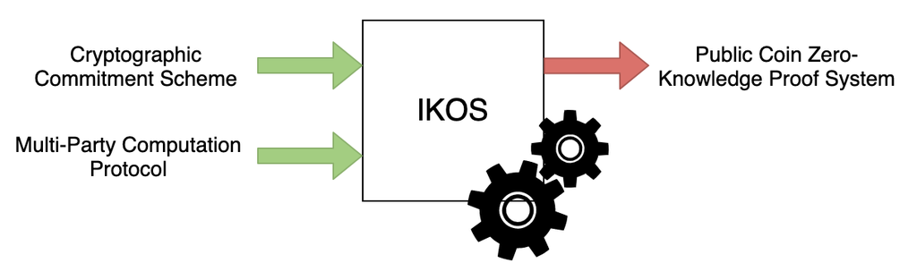

IKOS compiler (source: [Trail of Bits blog](https://blog.trailofbits.com/2020/12/14/reverie-an-optimized-zero-knowledge-proof-system/))

Any proof constructed from the IKOS compiler requires 3 rounds of communication between Peggy and Victor, and the total amount of data sent is about $k$ times the size of the check program $C$.

## 22.3 Non-interactive proofs

Next, let’s transform this ZK proof into a 1-round protocol – that is, a **single** message sent by Peggy.

- A non-interactive proof is *publicly verifiable*: rather than being directed to a single verifier Victor, the whole world can check that Peggy is telling the truth
- A non-interactive proof is *transferable*: anyone who receives the proof can forward it along to others

The key insight here comes from inspecting Victor’s message in round 2 of the protocol.

- It is a uniformly random selection of which compute server views to open
- It is stateless: Victor does not keep anything secret from Peggy after making his selection

[figure not shown]

MPC-in-the-head (source: [Trail of Bits blog](https://blog.trailofbits.com/2020/12/14/reverie-an-optimized-zero-knowledge-proof-system/))

As a result, Victor’s algorithm is so simple that we would like to ask Peggy to perform this action on Victor’s behalf. This would eliminate Victor’s need to interact in the ZK proof at all; he only needs to perform the final verification step at the end.

**Question.** What could go wrong if we ask Peggy to create the challenge (of which servers to open) rather than Victor?

*Answer*. The concern is that Peggy could choose the challenges dishonestly, rather than randomly.

- Specifically, Peggy might have executed some of the MPC servers in a dishonest manner. If we allow Peggy to control which servers are opened, then she might choose always to avoid the dishonest servers so that she is never caught in a lie.
- So: we want Peggy to select the challenge uniformly at random, but in a way that is outside her control to tamper with.

### The Fiat-Shamir transform

Amos Fiat and Adi Shamir came up with a clever way to do this: use a cryptographic hash function! Namely, remember that one strong assumption we can make about a hash function $H$ is that it acts like a **random oracle**, i.e., as if it is a randomly-generated truth table.

The Fiat-Shamir transform converts an interactive proof into a non-interactive one, by telling the prover Peggy to compute Victor’s challenge *as a cryptographic hash function* applied to the statement $x$ and her first message of the protocol.

In this way, Peggy’s own commitments end up selecting the challenge message, but in a way that is difficult for her to predict or control.

In detail, Peggy performs the following:

- Run the MPC servers and form commitments $\vec{c}$ to all of the views.
- Compute $r = H(x, \vec{c})$ and treat this random value as Victor’s challenge.
- Open the corresponding views in response to Victor’s challenge.
- Send *everything* to Victor in one round of communication.

This construction can be proved to satisfy all of the ZK properties, although I won’t show that here.

Remember that one advantage of a non-interactive zero knowledge proof is that we can post it to a blockchain, in order to convince the whole world that (for instance) a financial transaction is sound. We’ll discuss ZK in the context of blockchains next time.

### An aside: From ZK to digital signatures

When they proposed this transformation, Fiat and Shamir were not trying to to build non-interactive ZK. Instead, their goal was to build digital signatures!

If you think about it, a digital signature is just a special case of a zero knowledge proof.

**Definition** of a *digital signature*.

- `KeyGen`: produces keys $sk$ and $pk$
- `Sign`${}_{sk}(m)$: produces a signature $\sigma$
- `Verify`${}_{pk}(m, \sigma)$: returns `true` or `false`

**Construction** of a digital signature using a ZK proof.

- `KeyGen`: sample $sk$ at random, let $pk = H(sk)$
- `Sign`${}_{sk}(m)$: create a non-interactive ZK proof $\sigma$ for the statement “I know $sk$ that is the preimage to $pk$, *and* I approve the message $M$”
- `Verify`$_{pk}(m, \sigma)$: check the validity of the proof

As a result, one can build a digital signature scheme using *only a cryptographic hash function $H$* (and a ZK proof, which using MPC-in-the-head also only needs $H$ to make a message commitment).

In particular, this digital signature does *not* rely on assumptions about discrete log or factoring!

- That’s helpful because discrete logs and factoring are known to be breakable if someone ever builds a sufficiently-large *quantum computer*
- To plan ahead, NIST organized a [post-quantum cryptography competition](https://csrc.nist.gov/projects/post-quantum-cryptography) for the past decade to study and standardize replacements for the current systems that we use for public-key cryptography (the idea that I described above is one of many proposals they considered)

## 22.4 zk-SNARKs

Switching gears, for the rest of today’s lecture I will give you a brief glimpse into the cutting-edge of ZK. There has been a substantial amount of work over the past decade to construct **zk-SNARKs**. These are:

- **z**ero **k**nowledge
- **s**uccinct
- **n**on-interactive
- **ar**guments of **k**nowledge

The word “snark” comes from a [poem by Lewis Carroll](https://en.wikipedia.org/wiki/The_Hunting_of_the_Snark), in which several people are hunting a fictional animal that he calls a *snark*.

Also: for the purposes of this course, let’s think of the words “proof” and “argument” as synonyms.

These proofs are *very* small, say just a few hundred bytes in size. This is true even if:

- the analysis involves a large volume of data (say, gigabytes or terabytes), and/or
- the analysis itself is computationally intensive (say, a high-performance machine learning algorithm).

Here are some [potential applications of zk-SNARKs](https://medium.com/@imolfar/why-and-how-zk-snark-works-1-introduction-the-medium-of-a-proof-d946e931160):

- A bank can prove that from all of their transactions over the past year, they did not transact with some entity $Y$… but without revealing their full transaction log.
- Outsourcing a large computation to the cloud, and then validating that the result is correct without redoing the work yourself.
- Building private cryptocurrencies (our task for next lecture)

### Why this is hard

Let me give you a glimpse into how zk-SNARKs are built. The main challenge is to provide **succinctness** and **soundness** together. (Adding *zero knowledgeness* on top of this is fairly easy.)

As a starting point: let’s think about what you might do to verify a computation done by someone else, if ZK and succinctness were *not* needed. Here is one approach:

- When the untrusted prover performs the computation, you can also ask them to write down their work at each step
- After they are done, you can review all of their work and check that they have done it correctly

**Example.** Suppose that you outsource to the cloud the act of calculating $2^{20}$. For now, let’s pretend that the only way to calculate this number is to multiply the number $2$ a total of $20$ times.

- Suppose the cloud messes up in one step of the calculation, and here is the work that they show you.
- Rather than calculating $8192 \times 2 = 16,384$ the cloud instead produces the cell $15,625$.
- As a consequence, the cloud tells you that $2^{20} = 1$ million.
- If you see the entire working state of the cloud computer, then you can catch this bug!

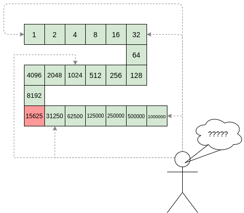

Transcript of an erroneous computation (source: [Vitalik Buterin’s blog](https://vitalik.ca/general/2021/01/26/snarks.html))

**Question.** If the cloud can only send you a small amount of data, of your choice, then what should you request? (Asking for just part of the working state will not work, as the cloud could lie elsewhere.)

What you need is some way to *bind together* all of the cloud’s working state $1, 2, 4, 8, \ldots$ into some object that is:

- Succinct, but also
- Brittle, in the sense that if you tamper with even a single number then the object will be wildly different most of the time.

### Why this is possible

One mathematical object with this property is **polynomials**. They have the property that if you change a polynomial at even one point, then you end up changing it at *nearly every point*.

Or in other words:

> Two different polynomials $P$ and $Q$, each of degree $d$, intersect in at most $d$ points.

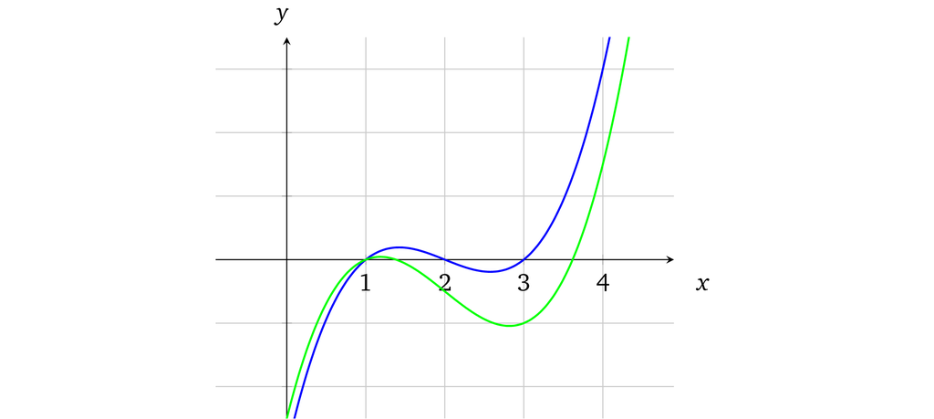

Two polynomials (source: [Why and How zk-SNARK Works](https://medium.com/@imolfar/why-and-how-zk-snark-works-1-introduction-the-medium-of-a-proof-d946e931160))

Does this solve the problem?

- The bad news: polynomials are not succinct. To describe a polynomial of a large degree $d$, you need to write $d+1$ coefficients.
- The good news: **polynomial commitments** are succinct. These are special commitments that allow Peggy to put a polynomial $P$ in a (digital) envelope, and then open $P$ at points of Victor’s choosing.

Amazingly, it is possible to transform the action of “verifying an arbitrary program outsourced to the cloud” into “verifying some polynomial arithmetic.” This is what modern ZK proofs do!

I know the math of zk-SNARKs is complicated; the most important things to remember are that:

- Creating a zk-SNARK is mathematically possible: I can send you a **short** message that will convince you that I performed a data science analysis correctly
- There are ZK computer programs that handle all this math for you, behind the scenes

For more details on the “moon math” of polynomials and rank-1 constraint systems, read [this blog post](https://medium.com/@VitalikButerin/quadratic-arithmetic-programs-from-zero-to-hero-f6d558cea649) by Vitalik Buterin, the creator of Ethereum.